# Real Estate Price Prediction

**Data Source:**  
**Taiwan real estate price prediction dataset, *Quant Bruce*.**  
**Retrieved from** https://www.kaggle.com/datasets/quantbruce/real-estate-price-prediction/data

In this analysis, I used a multiple linear regression model to predict house prices based on features such as house age, distance to the nearest MRT station, number of nearby convenience stores, and geographic coordinates (latitude and longitude). I cleaned the dataset, handled outliers, performed feature scaling and multicollinearity checks, and evaluated the model on unseen test data. The model was implemented using `scikit-learn` in Python.

## Importing the relevan libraries

```python
import numpy as np
import pandas as pd
import statsmodels.api as sm
import matplotlib.pyplot as plt
from sklearn.linear_model import LinearRegression
import seaborn as sns
sns.set()
```

## Loading the raw data

```python
raw_data = pd.read_csv('Real-estate.csv')
raw_data.head()
```

|  | No | X1 transaction date | X2 house age | X3 distance to the nearest MRT station | X4 number of convenience stores | X5 latitude | X6 longitude | Y house price of unit area |
| --- | --- | --- | --- | --- | --- | --- | --- | --- |
| 0 | 1 | 2012.917 | 32.0 | 84.87882 | 10 | 24.98298 | 121.54024 | 37.9 |
| 1 | 2 | 2012.917 | 19.5 | 306.59470 | 9 | 24.98034 | 121.53951 | 42.2 |
| 2 | 3 | 2013.583 | 13.3 | 561.98450 | 5 | 24.98746 | 121.54391 | 47.3 |
| 3 | 4 | 2013.500 | 13.3 | 561.98450 | 5 | 24.98746 | 121.54391 | 54.8 |
| 4 | 5 | 2012.833 | 5.0 | 390.56840 | 5 | 24.97937 | 121.54245 | 43.1 |

## Preprocessing

### Exploring the descriptive statistics of the variables

```python
raw_data.describe(include='all')
```

|  | No | X1 transaction date | X2 house age | X3 distance to the nearest MRT station | X4 number of convenience stores | X5 latitude | X6 longitude | Y house price of unit area |
| --- | --- | --- | --- | --- | --- | --- | --- | --- |
| count | 414.000000 | 414.000000 | 414.000000 | 414.000000 | 414.000000 | 414.000000 | 414.000000 | 414.000000 |
| mean | 207.500000 | 2013.148971 | 17.712560 | 1083.885689 | 4.094203 | 24.969030 | 121.533361 | 37.980193 |
| std | 119.655756 | 0.281967 | 11.392485 | 1262.109595 | 2.945562 | 0.012410 | 0.015347 | 13.606488 |
| min | 1.000000 | 2012.667000 | 0.000000 | 23.382840 | 0.000000 | 24.932070 | 121.473530 | 7.600000 |
| 25% | 104.250000 | 2012.917000 | 9.025000 | 289.324800 | 1.000000 | 24.963000 | 121.528085 | 27.700000 |
| 50% | 207.500000 | 2013.167000 | 16.100000 | 492.231300 | 4.000000 | 24.971100 | 121.538630 | 38.450000 |
| 75% | 310.750000 | 2013.417000 | 28.150000 | 1454.279000 | 6.000000 | 24.977455 | 121.543305 | 46.600000 |
| max | 414.000000 | 2013.583000 | 43.800000 | 6488.021000 | 10.000000 | 25.014590 | 121.566270 | 117.500000 |

### Determining the variables of interest

I removed two columns: 'No' and 'X1 transaction date'. The No column is just an index and doesn’t contain useful information. The transaction date, while technically a feature, spans only a short period (mid-2012 to mid-2013) and doesn't provide enough variation to be helpful for prediction. Dropping both helps keep the dataset clean and focused on meaningful variables.

```python
data = raw_data.drop(['No','X1 transaction date'],axis=1)

# Let's check the descriptives without 'Model'
data.describe(include='all')
```

|  | X2 house age | X3 distance to the nearest MRT station | X4 number of convenience stores | X5 latitude | X6 longitude | Y house price of unit area |
| --- | --- | --- | --- | --- | --- | --- |
| count | 414.000000 | 414.000000 | 414.000000 | 414.000000 | 414.000000 | 414.000000 |
| mean | 17.712560 | 1083.885689 | 4.094203 | 24.969030 | 121.533361 | 37.980193 |
| std | 11.392485 | 1262.109595 | 2.945562 | 0.012410 | 0.015347 | 13.606488 |
| min | 0.000000 | 23.382840 | 0.000000 | 24.932070 | 121.473530 | 7.600000 |
| 25% | 9.025000 | 289.324800 | 1.000000 | 24.963000 | 121.528085 | 27.700000 |
| 50% | 16.100000 | 492.231300 | 4.000000 | 24.971100 | 121.538630 | 38.450000 |
| 75% | 28.150000 | 1454.279000 | 6.000000 | 24.977455 | 121.543305 | 46.600000 |
| max | 43.800000 | 6488.021000 | 10.000000 | 25.014590 | 121.566270 | 117.500000 |

### Dealing with missing values

```python
data.isnull().sum()
```

```
X2 house age                              0
X3 distance to the nearest MRT station    0
X4 number of convenience stores           0
X5 latitude                               0
X6 longitude                              0
Y house price of unit area                0
dtype: int64
```

No missing value

### Exploring the PDFs

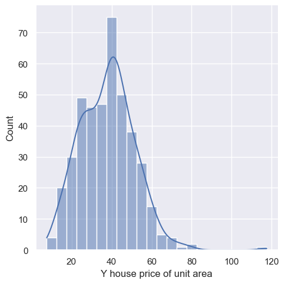

```python
sns.displot(data=data, x='Y house price of unit area', kde=True)
```

### Dealing with outliers

The histogram above shows the distribution of house price per unit area (in NT$ per ping). Most values fall between 20 and 60, with a noticeable peak around 40. However, we can also see that the distribution is slightly right-skewed, with a few properties priced above 80, and even beyond 100.

These extremely high prices are considered outliers — they are very different from the majority of the data and may not reflect typical market conditions. If left in the dataset, they can distort the regression model, pulling the line of best fit toward them and reducing overall accuracy for the rest of the predictions.

To create a more balanced model that better represents most properties, I decided to remove the top 1% of highest-priced data points. This helps reduce skew and improve the model’s performance and stability.

```python
q = data['Y house price of unit area'].quantile(0.99)
data_1 = data[data['Y house price of unit area']<q]
data_1.describe()
```

|  | X2 house age | X3 distance to the nearest MRT station | X4 number of convenience stores | X5 latitude | X6 longitude | Y house price of unit area |
| --- | --- | --- | --- | --- | --- | --- |
| count | 409.000000 | 409.000000 | 409.000000 | 409.000000 | 409.000000 | 409.000000 |
| mean | 17.725183 | 1093.850998 | 4.068460 | 24.968952 | 121.533273 | 37.421516 |
| std | 11.314879 | 1266.559410 | 2.936452 | 0.012462 | 0.015409 | 12.565902 |
| min | 0.000000 | 23.382840 | 0.000000 | 24.932070 | 121.473530 | 7.600000 |
| 25% | 9.100000 | 289.324800 | 1.000000 | 24.962990 | 121.527600 | 27.300000 |
| 50% | 16.100000 | 492.231300 | 4.000000 | 24.971100 | 121.538630 | 38.300000 |
| 75% | 28.000000 | 1455.798000 | 6.000000 | 24.977950 | 121.543290 | 46.100000 |
| max | 43.800000 | 6488.021000 | 10.000000 | 25.014590 | 121.566270 | 70.100000 |

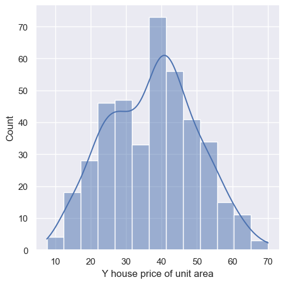

```python
sns.displot(data=data_1, x='Y house price of unit area', kde=True)
```

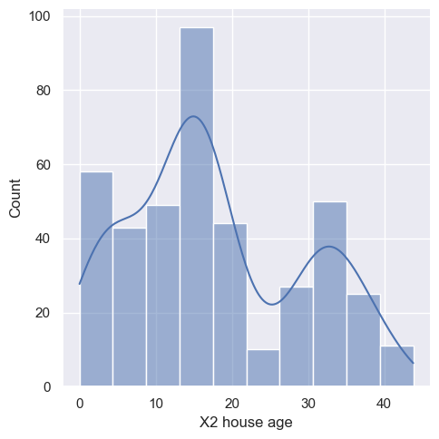

```python
sns.displot(data=data, x='X2 house age', kde=True)
```

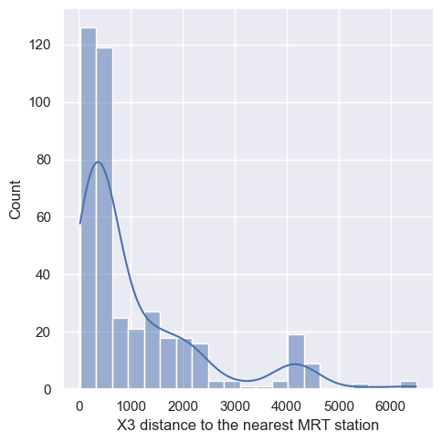

```python
sns.displot(data=data, x='X3 distance to the nearest MRT station', kde=True)
```

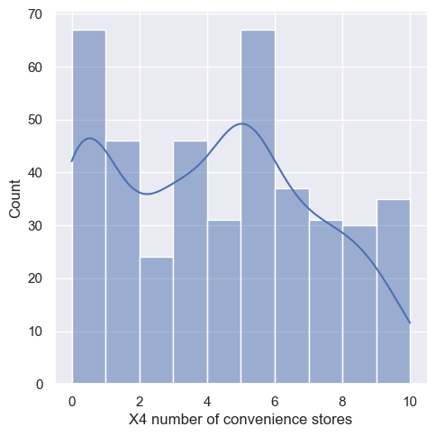

```python
sns.displot(data=data, x='X4 number of convenience stores', kde=True)
```

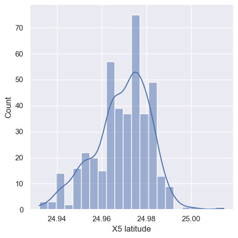

```python
sns.displot(data=data, x='X5 latitude', kde=True)
```

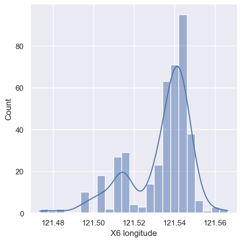

```python
sns.displot(data=data, x='X6 longitude', kde=True)
```

All other data appears to be appropriate, with values that fall within a reasonable and meaningful range.

```python
data_cleaned = data_1.reset_index(drop=True)
```

```python
data_cleaned.describe(include='all')
```

|  | X2 house age | X3 distance to the nearest MRT station | X4 number of convenience stores | X5 latitude | X6 longitude | Y house price of unit area |
| --- | --- | --- | --- | --- | --- | --- |
| count | 409.000000 | 409.000000 | 409.000000 | 409.000000 | 409.000000 | 409.000000 |
| mean | 17.725183 | 1093.850998 | 4.068460 | 24.968952 | 121.533273 | 37.421516 |
| std | 11.314879 | 1266.559410 | 2.936452 | 0.012462 | 0.015409 | 12.565902 |
| min | 0.000000 | 23.382840 | 0.000000 | 24.932070 | 121.473530 | 7.600000 |
| 25% | 9.100000 | 289.324800 | 1.000000 | 24.962990 | 121.527600 | 27.300000 |
| 50% | 16.100000 | 492.231300 | 4.000000 | 24.971100 | 121.538630 | 38.300000 |
| 75% | 28.000000 | 1455.798000 | 6.000000 | 24.977950 | 121.543290 | 46.100000 |
| max | 43.800000 | 6488.021000 | 10.000000 | 25.014590 | 121.566270 | 70.100000 |

Data description after removing the outliers

## Checking the OLS assumptions

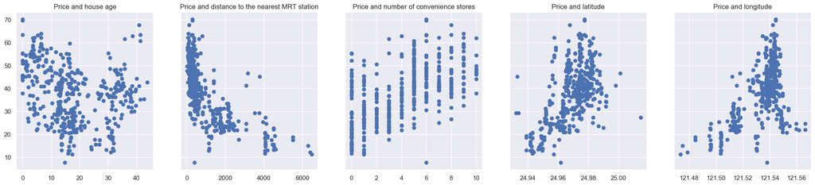

```python
f, (ax1, ax2, ax3, ax4, ax5) = plt.subplots(1, 5, sharey=True, figsize =(25,5)) #sharey -> share 'Price' as y
ax1.scatter(data_cleaned['X2 house age'],data_cleaned['Y house price of unit area'])
ax1.set_title('Price and house age')
ax2.scatter(data_cleaned['X3 distance to the nearest MRT station'],data_cleaned['Y house price of unit area'])
ax2.set_title('Price and distance to the nearest MRT station')
ax3.scatter(data_cleaned['X4 number of convenience stores'],data_cleaned['Y house price of unit area'])
ax3.set_title('Price and number of convenience stores')
ax4.scatter(data_cleaned['X5 latitude'],data_cleaned['Y house price of unit area'])
ax4.set_title('Price and latitude')
ax5.scatter(data_cleaned['X6 longitude'],data_cleaned['Y house price of unit area'])
ax5.set_title('Price and longitude')

plt.show()
```

We will transform the MRT distance feature, as its relationship with the target variable appears to be non-linear. Applying a log transformation would be appropriate to reduce skewness and better capture the underlying pattern in the data.

```python
Transform_data = np.log(data_cleaned['X3 distance to the nearest MRT station'])
data_cleaned['log distance to the nearest MRT station'] = Transform_data
data_cleaned
```

|  | X2 house age | X3 distance to the nearest MRT station | X4 number of convenience stores | X5 latitude | X6 longitude | Y house price of unit area | log distance to the nearest MRT station |
| --- | --- | --- | --- | --- | --- | --- | --- |
| 0 | 32.0 | 84.87882 | 10 | 24.98298 | 121.54024 | 37.9 | 4.441225 |
| 1 | 19.5 | 306.59470 | 9 | 24.98034 | 121.53951 | 42.2 | 5.725527 |
| 2 | 13.3 | 561.98450 | 5 | 24.98746 | 121.54391 | 47.3 | 6.331474 |
| 3 | 13.3 | 561.98450 | 5 | 24.98746 | 121.54391 | 54.8 | 6.331474 |
| 4 | 5.0 | 390.56840 | 5 | 24.97937 | 121.54245 | 43.1 | 5.967603 |
| ... | ... | ... | ... | ... | ... | ... | ... |
| 404 | 13.7 | 4082.01500 | 0 | 24.94155 | 121.50381 | 15.4 | 8.314346 |
| 405 | 5.6 | 90.45606 | 9 | 24.97433 | 121.54310 | 50.0 | 4.504864 |
| 406 | 18.8 | 390.96960 | 7 | 24.97923 | 121.53986 | 40.6 | 5.968630 |
| 407 | 8.1 | 104.81010 | 5 | 24.96674 | 121.54067 | 52.5 | 4.652150 |
| 408 | 6.5 | 90.45606 | 9 | 24.97433 | 121.54310 | 63.9 | 4.504864 |

409 rows × 7 columns

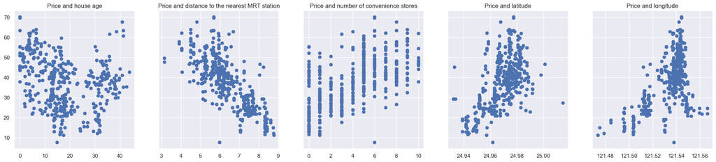

```python
f, (ax1, ax2, ax3, ax4, ax5) = plt.subplots(1, 5, sharey=True, figsize =(25,5)) #sharey -> share 'Price' as y
ax1.scatter(data_cleaned['X2 house age'],data_cleaned['Y house price of unit area'])
ax1.set_title('Price and house age')
ax2.scatter(data_cleaned['log distance to the nearest MRT station'],data_cleaned['Y house price of unit area'])
ax2.set_title('Price and distance to the nearest MRT station')
ax3.scatter(data_cleaned['X4 number of convenience stores'],data_cleaned['Y house price of unit area'])
ax3.set_title('Price and number of convenience stores')
ax4.scatter(data_cleaned['X5 latitude'],data_cleaned['Y house price of unit area'])
ax4.set_title('Price and latitude')
ax5.scatter(data_cleaned['X6 longitude'],data_cleaned['Y house price of unit area'])
ax5.set_title('Price and longitude')

plt.show()
```

After applying a log transformation to the MRT distance feature, the relationship between this variable and house price per unit area becomes more linear and easier to interpret. The second plot in the figure ("Price and distance to the nearest MRT station") now shows a clearer negative trend, indicating that as the (log) distance to the MRT station increases, the property price tends to decrease. This transformation helps reduce the skewness and compress the extreme values, making the pattern more stable for linear regression.

In the other scatter plots, we observe the following:

```
House age continues to show a weak negative relationship with price, though it's scattered — older houses tend to have lower prices per unit area, but not strictly.

Number of convenience stores displays a loose positive relationship — generally, more stores nearby are associated with higher prices.

Latitude and longitude clearly show that price varies by location. There are dense clusters indicating more expensive neighborhoods, highlighting the spatial influence on property value.
```

Overall, the log transformation improves the interpretability of the MRT feature and makes the dataset more suitable for a linear regression model. The other features remain valuable and show logical relationships with the target variable.

### Multicollinearity

```python
data_cleaned = data_cleaned.drop(['X3 distance to the nearest MRT station'],axis=1)
data_cleaned.rename(columns={"log distance to the nearest MRT station": "log_mrt_distance"}, inplace=True)
data_cleaned.columns.values
```

```
array(['X2 house age', 'X4 number of convenience stores', 'X5 latitude',
       'X6 longitude', 'Y house price of unit area', 'log_mrt_distance'],
      dtype=object)
```

```python
from statsmodels.stats.outliers_influence import variance_inflation_factor
variables = data_cleaned[['X2 house age','X4 number of convenience stores','X5 latitude','X6 longitude','log_mrt_distance']]
vif = pd.DataFrame()
vif["VIF"] = [variance_inflation_factor(variables.values, i) for i in range(variables.shape[1])]
vif["Features"] = variables.columns
```

```python
vif
```

|  | VIF | Features |
| --- | --- | --- |
| 0 | 3.551377e+00 | X2 house age |
| 1 | 5.858029e+00 | X4 number of convenience stores |
| 2 | 5.483178e+06 | X5 latitude |
| 3 | 5.484897e+06 | X6 longitude |
| 4 | 6.557071e+01 | log_mrt_distance |

To ensure the reliability of our regression model, we performed a multicollinearity check using the Variance Inflation Factor (VIF). Multicollinearity occurs when two or more independent variables are highly correlated with each other, making it difficult for the model to estimate their individual effects accurately. High multicollinearity can lead to unstable coefficients, inflated standard errors, and misleading interpretations. Upon further inspection, we found that log_mrt_distance is strongly correlated with latitude and longitude, which makes sense — houses closer to MRT stations tend to be concentrated in specific geographic areas. Because latitude and longitude provide richer spatial information, we decided to drop log_mrt_distance to reduce redundancy and improve model stability.

This step helps ensure our model is both interpretable and statistically sound.

```python
data_cleaned = data_cleaned.drop(['log_mrt_distance'],axis=1)
data_cleaned
```

|  | X2 house age | X4 number of convenience stores | X5 latitude | X6 longitude | Y house price of unit area |
| --- | --- | --- | --- | --- | --- |
| 0 | 32.0 | 10 | 24.98298 | 121.54024 | 37.9 |
| 1 | 19.5 | 9 | 24.98034 | 121.53951 | 42.2 |
| 2 | 13.3 | 5 | 24.98746 | 121.54391 | 47.3 |
| 3 | 13.3 | 5 | 24.98746 | 121.54391 | 54.8 |
| 4 | 5.0 | 5 | 24.97937 | 121.54245 | 43.1 |
| ... | ... | ... | ... | ... | ... |
| 404 | 13.7 | 0 | 24.94155 | 121.50381 | 15.4 |
| 405 | 5.6 | 9 | 24.97433 | 121.54310 | 50.0 |
| 406 | 18.8 | 7 | 24.97923 | 121.53986 | 40.6 |
| 407 | 8.1 | 5 | 24.96674 | 121.54067 | 52.5 |
| 408 | 6.5 | 9 | 24.97433 | 121.54310 | 63.9 |

409 rows × 5 columns

we dont need create dummy variable since it has no categorical value

## Linear regression model

### Declare the inputs and the targets

```python
targets = data_cleaned['Y house price of unit area']
inputs = data_cleaned.drop(['Y house price of unit area'],axis=1)
```

### Scale the data

Before training the regression model, we apply feature scaling using StandardScaler from scikit-learn. This process standardizes the input features by removing the mean and scaling them to unit variance — in other words, it transforms each feature to have a mean of 0 and a standard deviation of 1.

By calling scaler.fit(inputs), we instruct the scaler to learn the mean and standard deviation of each feature in the training data. These values are then used to transform the data consistently, ensuring all features contribute equally to the model.

```python
from sklearn.preprocessing import StandardScaler
scaler = StandardScaler()
scaler.fit(inputs)
```

```
StandardScaler()
```

```python
inputs_scaled = scaler.transform(inputs)
```

### Train Test Split

In this step, we use train_test_split from sklearn.model_selection to divide our dataset into a training set and a test set. Specifically, we apply an 80/20 split, where 80% of the data is used to train the regression model, and the remaining 20% is reserved for testing the model's performance on unseen data.

This separation is essential in supervised learning because it allows us to evaluate how well the model generalizes — that is, how accurately it can make predictions on data it hasn't seen before. Without this split, we could end up building a model that performs well on training data but poorly in real-world scenarios (a problem known as overfitting).

```python
from sklearn.model_selection import train_test_split
x_train, x_test, y_train, y_test = train_test_split(inputs_scaled, targets, test_size=0.2, random_state=365)
```

### Create the regression

```python
reg = LinearRegression()
reg.fit(x_train,y_train)
```

```
LinearRegression()
```

```python
y_hat = reg.predict(x_train)
```

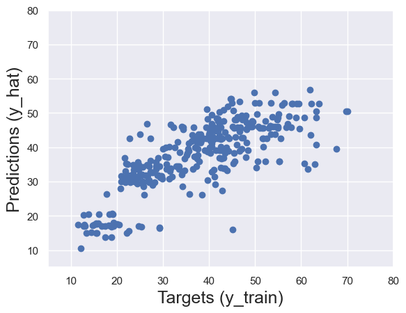

```python
plt.scatter(y_train, y_hat)
plt.xlabel('Targets (y_train)',size=18)
plt.ylabel('Predictions (y_hat)',size=18)
plt.xlim(5,80)
plt.ylim(5,80)
plt.show()
```

In this plot, most points follow a positive upward trend, indicating that the model captures the general relationship between features and target.

However, there's some scatter, especially at higher price values, suggesting the model isn't perfect and may underpredict or overpredict in some case

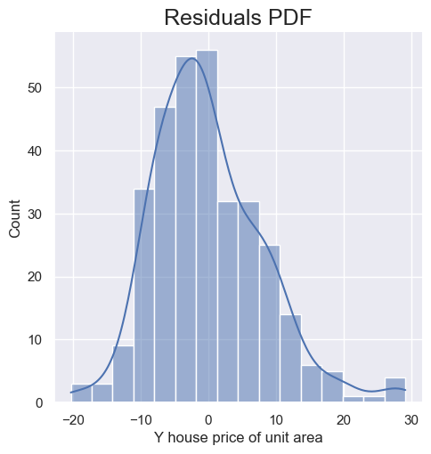

```python
sns.displot(y_train - y_hat, kde=True)
plt.title("Residuals PDF", size=18)
```

The model’s errors appear fairly good, supporting the validity of the regression results.

```python
reg.score(x_train,y_train)
```

```
0.6088210426820677
```

This means the model explains approximately 61% of the variance in house price per unit area based on the selected features.

### Finding the weights and bias

```python
reg.intercept_
```

```
37.65522267975206
```

```python
reg.coef_
```

```
array([-3.05369106,  5.02641514,  3.75806973,  3.00445494])
```

```python
reg_summary = pd.DataFrame(inputs.columns.values, columns=['Features'])
reg_summary['Weights'] = reg.coef_
reg_summary
```

|  | Features | Weights |
| --- | --- | --- |
| 0 | X2 house age | -3.053691 |
| 1 | X4 number of convenience stores | 5.026415 |
| 2 | X5 latitude | 3.758070 |
| 3 | X6 longitude | 3.004455 |

The table above summarizes the weights (or coefficients) assigned to each feature by the linear regression model. These values indicate the strength and direction of the relationship between each independent variable and the house price per unit area. A negative weight, such as the one for house age (-3.05), suggests that as houses get older, their price per unit area tends to decrease. In contrast, the number of convenience stores has a strong positive weight (+5.03), indicating that properties located near more stores are generally more expensive. The positive weights for both latitude (+3.76) and longitude (+3.00) suggest that location plays a significant role in determining house prices — with properties situated further north and east tending to be priced higher. Since the features were standardized before training, these weights reflect the change in predicted price per unit area for every one standard deviation increase in the corresponding feature, helping us interpret the relative importance and influence of each input variable.

## Testing

```python
y_hat_test = reg.predict(x_test)
```

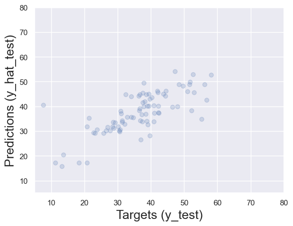

```python
plt.scatter(y_test, y_hat_test, alpha=0.2)
plt.xlabel('Targets (y_test)',size=18)
plt.ylabel('Predictions (y_hat_test)',size=18)
plt.xlim(5,80)
plt.ylim(5,80)
plt.show()
```

This scatter plot compares the predicted house prices (y_hat_test) to the actual prices (y_test) from the test set. Each point represents one observation, with the true value on the x-axis and the predicted value on the y-axis.

Ideally, all points should align closely along an imaginary diagonal line (45-degree line), which would indicate perfect predictions. In this plot, we observe a positive trend, showing that the model is generally able to predict higher prices for more expensive houses and lower prices for cheaper ones. However, the points are somewhat scattered, particularly for lower and higher values, suggesting that the model may struggle slightly with extreme cases.

This plot provides a visual way to evaluate the generalization performance of the model on unseen data — how well it performs beyond the training set. Although not perfect, the pattern suggests that the model has learned a reasonable mapping from the input features to the target variable.

```python
df_pf = pd.DataFrame(y_hat_test, columns=['Prediction'])
df_pf['Target'] = y_test.values
df_pf['Residual'] = df_pf['Target'] - df_pf['Prediction']
df_pf['Difference%'] = (df_pf['Residual'].abs() / df_pf['Target']) * 100

df_pf = df_pf.round(2)
df_pf.sort_values(by='Difference%', ascending=False).head(10)
```

|  | Prediction | Target | Residual | Difference% |
| --- | --- | --- | --- | --- |
| 63 | 40.52 | 7.6 | -32.92 | 433.14 |
| 10 | 35.22 | 21.4 | -13.82 | 64.59 |
| 25 | 17.27 | 11.2 | -6.07 | 54.20 |
| 6 | 31.91 | 20.8 | -11.11 | 53.41 |
| 14 | 20.47 | 13.7 | -6.77 | 49.39 |
| 80 | 44.73 | 32.4 | -12.33 | 38.07 |
| 67 | 34.95 | 55.3 | 20.35 | 36.80 |
| 54 | 49.56 | 37.9 | -11.66 | 30.76 |
| 62 | 28.20 | 39.7 | 11.50 | 28.96 |
| 20 | 30.69 | 23.8 | -6.89 | 28.95 |

This table displays the test samples with the highest prediction errors, sorted by percentage difference. While most predictions fall within a reasonable range, a few outliers show large residuals — the worst case being a 433% error. These results highlight that the model generally performs well but may struggle with edge cases or unusual data points, suggesting areas where further refinement or feature engineering could improve accuracy.

```python
df_pf.describe()
```

|  | Prediction | Target | Residual | Difference% |
| --- | --- | --- | --- | --- |
| count | 82.000000 | 82.000000 | 82.000000 | 82.000000 |
| mean | 37.575000 | 36.409756 | -1.165244 | 19.650122 |
| std | 8.325708 | 10.709954 | 7.100729 | 48.020146 |
| min | 15.900000 | 7.600000 | -32.920000 | 0.270000 |
| 25% | 32.110000 | 30.525000 | -4.680000 | 5.292500 |
| 50% | 37.455000 | 37.450000 | -1.735000 | 10.995000 |
| 75% | 44.232500 | 42.175000 | 2.440000 | 20.115000 |
| max | 54.250000 | 58.100000 | 20.350000 | 433.140000 |

## Conclution

The residual analysis confirmed that errors are generally well distributed and centered around zero, supporting the model’s assumptions. While the model performs reliably in most cases, a few predictions resulted in significant errors, indicating the need for further refinement if high precision is required. Overall, the model is a solid baseline for predicting housing prices and offers clear insights into the most influential factors affecting property value in this dataset.